# Demonstration of gitwords

Taylor Spears

23 February 2015

```r
require("gitwords")
```

The three functions can be called with a single date or a range of dates as inputs. When get_words is called with a single date, it reports the word counts for that particular date. When word_stats and plot_words are called with a single date, they calculate summary statistics and build plots using all commits since that date:

```r
get_words(date="2013-12-01",
          repo="~/Dropbox/Repositories/Thesis")
```

```
##         Date Net Additions Net Modifications
## 1 2013-12-01           142               434
```

```r
word_stats(date="2013-07-01",
           repo="~/Dropbox/Repositories/Thesis")
```

```
## $`Summary Statistics`
##        Net Additions Net Modifications
## Mean            1424              6032
## Median          1204              4317
## StDev           1444              5479
## Min            -1958                 8
## Max             9825             27640
##
## $`Median by Day`
##                      Mon  Tue  Wed  Thu  Fri    Sat  Sun
## Net Additions     1129.0 1265 1337 1277 1322 1203.5  919
## Net Modifications 4962.5 3283 4348 4065 4548 4530.5 3980
```

[output not shown]

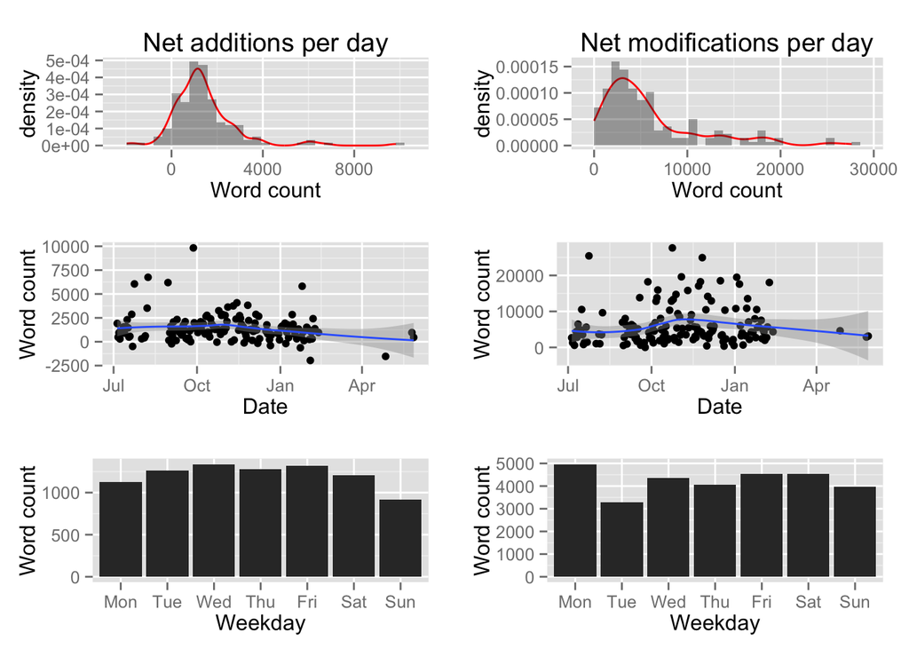

```r
plot_words(date="2013-07-01",
           repo="~/Dropbox/Repositories/Thesis")
```

You can also supply a range of dates to the functions, in which case all commits between those two dates are used:

```r
get_words(date=c("2013-12-01","2013-12-07"),
          repo="~/Dropbox/Repositories/Thesis")
```

```
##         Date Net Additions Net Modifications
## 1 2013-12-01           142               434
## 2 2013-12-02          1088             14164
## 3 2013-12-03          1140              2494
## 4 2013-12-04          1949              3747
## 5 2013-12-05          2866              5874
## 6 2013-12-06          1235             12931
## 7 2013-12-07          -164              4526
```

```r
word_stats(date=c("2013-07-01","2013-12-07"),
          repo="~/Dropbox/Repositories/Thesis")
```

```
## $`Summary Statistics`
##        Net Additions Net Modifications
## Mean            1607              6084
## Median          1271              4312
## StDev           1501              5692
## Min             -490                 8
## Max             9825             27640
##
## $`Median by Day`
##                      Mon  Tue  Wed    Thu  Fri    Sat  Sun
## Net Additions     1351.5 1265 1523 1250.0 1550 1185.5  944
## Net Modifications 4962.5 2733 5599 3393.5 6986 3801.0 3616
```

[output not shown]

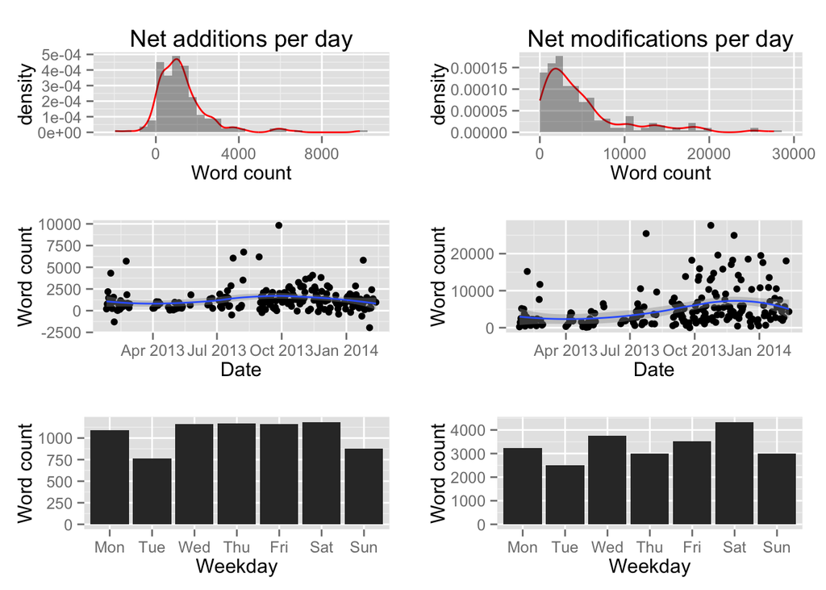

```r
plot_words(date=c("2013-01-01","2014-02-17"),
          repo="~/Dropbox/Repositories/Thesis")
```

Finally, you can omit providing the date altogether. Omitting the date parameter has different effects for the three functions. get_words will report word counts for today’s date if no date is supplied.

```r
get_words(repo="~/Dropbox/Repositories/Thesis")
```

```
## Error in subset_commits_date(a, date): No commits on 2015-02-25
```

which throws an error, since I have no commited any writing to my thesis repository today.

By comparison, word_stats and plot_words will use all commits in the repository if no date parameter is supplied:

```r
word_stats(repo="~/Dropbox/Repositories/Thesis")
```

```
## $`Summary Statistics`
##        Net Additions Net Modifications
## Mean            1264              5052
## Median          1013              3448
## StDev           1360              5137
## Min            -1958                 8
## Max             9825             27640
##
## $`Median by Day`
##                      Mon    Tue    Wed  Thu  Fri    Sat  Sun
## Net Additions     1024.5  765.0 1080.5 1168 1164 1185.5  854
## Net Modifications 3136.0 2516.5 3639.5 3006 3517 4335.0 3176
```

[output not shown]

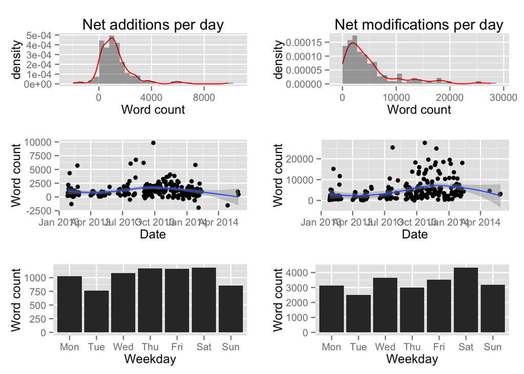

```r
plot_words(repo="~/Dropbox/Repositories/Thesis")
```

Finally, if you omit the repo parameter, then the functions will use your current working directory as the git repository. For example,

```r
setwd("~/Dropbox/Repositories/Thesis")
get_words(date="2013-12-01")
```

```
##         Date Net Additions Net Modifications
## 1 2013-12-01           142               434
```